[figure not shown]

- How much does each factor contribute to the stock performance
- During how many periods does each factor maintains effective
- Is there a pattern of the factor’s performance
- Is there a correlation between factors

## The main idea of multi-factor model

# Part One: The Factor Performance Report

## Data Procedure

- Sample space  
  This report sets the sample sapce to all component stocks of CSI 800 Index *(000906.SH)* which comprehensively includes most common types of stock in Chinese stock market. This report covers all data from the first trade day of 2013 and data will be gathered in a monthly sequence. The data is read from the Wind database through *Wind API* for R. (May demand certain membership to access the API)
- Standardization  
  In order to make different measurements with different dimensions comparable, data standardization is deployed for all observations before analyzation. There has three steps to obtain standardized and tidy data.
  1. Deal With Missing Value  
     In order to reduce the impact of missing values on the liability of my analyzation, I set three rules in dealing with them. First, the proportion of missing values is one of my concerns while choosing factors. I try to avoid taking in those factors whose data is hard to obtain. Second, since most of factor data is time series data, missing spaces are filled with the nearest historical data that does exist. Finally, those missing spaces with no available historical data will be remained missing in this step and being taken care of in the third sub step.
  2. Deal With Extreme Value  
     Despite of the satisfying application of MSCI Barra Model[^1] in the use of moving smoother as a way to move extrems. I find it inevitably erasing too much of valuable information when being applied to Chinese stock markets. Therefore, I decide to simply use the straightforward triple standard difference method.
  3. Remove dimension  
     We divide original data into cross-section data, which means we put together all the observations from different stocks at the same timepoint and remove their dimension as a whole. The common standardization method is applied: $\frac{x-\mu}{\sigma}$. (In which $\mu$ is the mean of each cross-section data and $\sigma$ is the standard variation).After this standardization, all data should has the same mean zero and a common variance of one.Those missing values being left in substep one can now be filled with zero.

## Factors

We divide all factors into two big categories: the industrial factors and the trait factors.

- Industrial Factors  
  Industrial factors identify the basic feature of a stock since stocks within the same industry are widely acknowledged for their similar movements and identiccal reactions towards external stimulations.
- Trait Factors  
  Trait factors try to explain why certain types of stocks perform better than others at during a particular time period. This report tries to point out those contributive factors and the circumstances in which they remain effective and thus deducing a guide in how to correctly use the factors.
- Evaluation Criterion Of Factors We will judge a factor in three ways:
1. The significance level between the factor indications and the stock performance  
   This significance level can be measured if we apply regression model to the cross-section data of a certain factor at each and every timepoint. The regression model should be a one-factor linear model with the factor indications of each stock as the independent variable and the stock performance within that period as the dependent variable. The t-value of the independent variable generated by the regression model is the significance level between the factor indications and the stock performance. And within our research, the t-value can be achieved from regressions at each timepoint and thus form a time-series sequence. The mean of that sequence may serve as the average significance level of that factor.
2. The proportion of effective timespans  
   Since the t-value of a factor forms a time-series sequence, we can determine the proportion of times when this factor significantly affects the performance of the stock. I define “significantly affect” as the t-value at that time point exceeds two (or less then minus two).
3. The performance of stocks with high or low factor indications  
   Within each period, I divide all stocks into five groups with the factor indications from low to high and thus generating five portofolios. Then I generate the strategy picking up the corresponding group at each period and back testing their performances. This could demonstrate whether a higher level of factor indication leads to a better performance or a lower one does.(Or maybe this factor has shifty influence on the performance and thus making it a bad factor.)

## Trait Factors: Beta

### What is beta

Beta is the correlation index between a certain stock and the index. Here we choose the *CSI 800 Index* as the reference and the time series span is set to be the past 100 weeks basing on daily frequency.

### The grouped portofolio backtest result

```
[1] "beta"
```

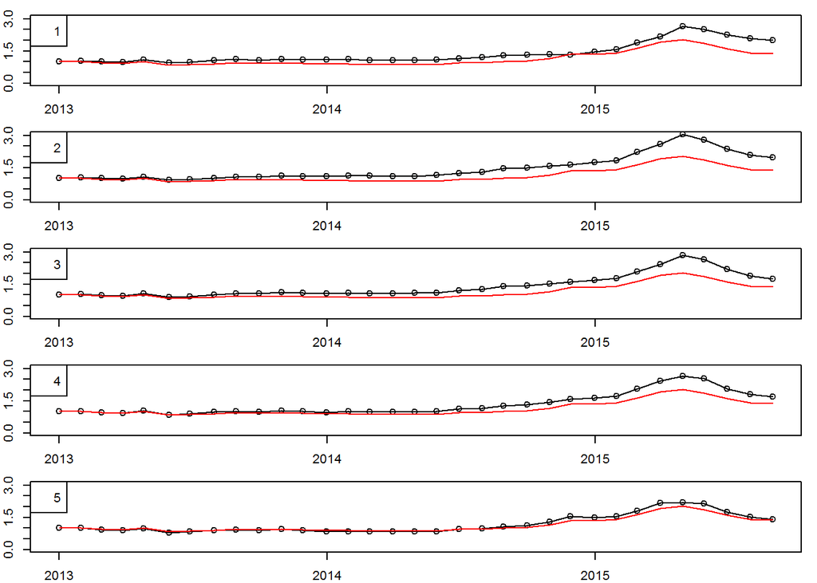

```
         [,1]      [,2]     [,3]      [,4]      [,5]
gain 2.013654 1.9636477 1.757396 1.6794272 1.4021931
     0.484900 0.5886386 0.530553 0.5179784 0.4300799
```

#### What does the plot mean

These plots shows the performance of five portofolios. The No.1 portofolio always includes those stocks with the lowest beta at last month and the No.5 has the highest. The red line is the reference index performance.  
The table below the plots shows the performance of each group. The first row shows the final value of each portofolio starts at one and the second row shows the standard deviation of each portofolio.

### The cross-section regression result

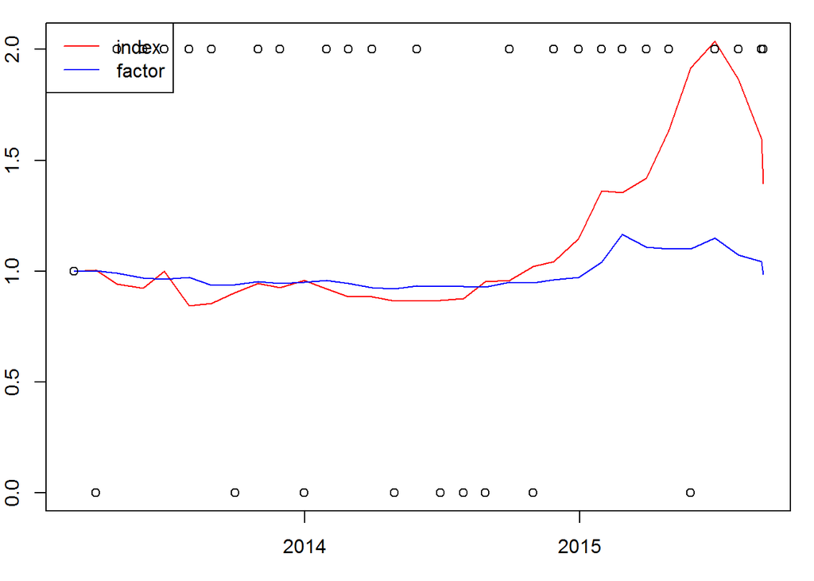

```
  average_t_value times_larger_than_threshold    rsquare
1        5.168851                   0.7096774 0.05242268
  average_factor_gain_year volatility_factor_gain
1                0.1926867               12.04279
```

#### What does the plot mean

This plot shows the regression result. The red line is the performance of our reference index and the blue line shows the performance of factor return, that is the coefficient of the factor generated by the regression model.Those points indicates whether the factor’s t-value is larger than the threshold or not. If it locates at the top of the plot than t-value exceeds threshold during that period and vice versa.  
The table below the plot shows detailed information including the average t-value, the proportion of t_value exceeding threshold, the total explanatory power of the regression model, the average annual yield of factor and the volatility of factor return.

It’s obvious to see that beta has a large t-value and a high proportion of times when its t-value exceeds threshold. Therefore, beta should be a rather effective factor.

**Conclusion**

[output not shown]

## Trait Factors: Momentum

### What is momentum

Momentum measures the historical perormance of this stock, it’s the average of the annual yield for the last 100 weeks. This factor may suggest whether those good stocks tend to maintain good or tend to become weak.

### The grouped portofolio backtest result

```
[1] "momentum"
```

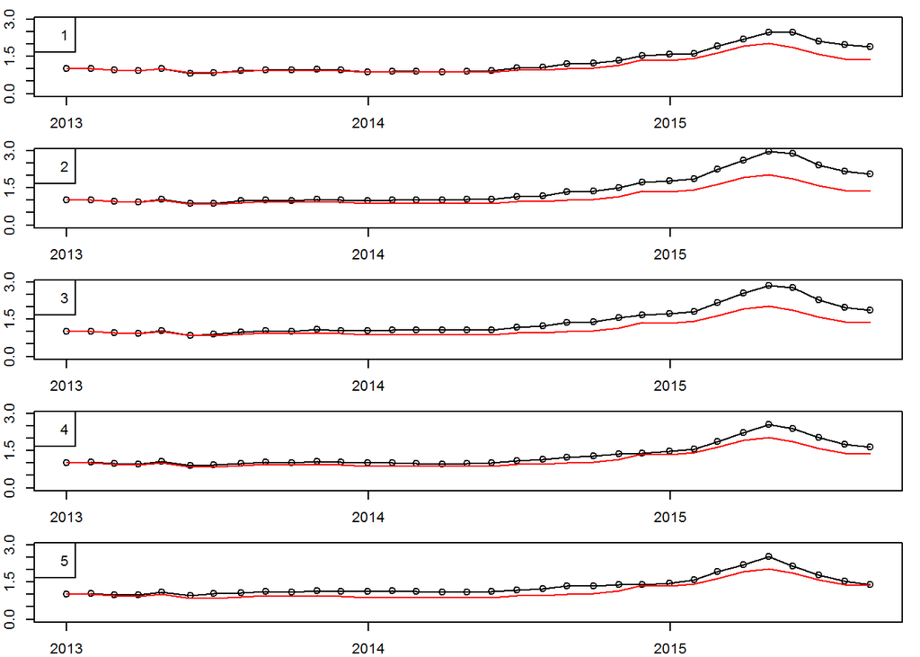

```
          [,1]      [,2]      [,3]      [,4]      [,5]
gain 1.8844672 2.0753914 1.8647006 1.6380351 1.3893224
     0.5110121 0.6292815 0.5738793 0.4578942 0.3900905
```

Stocks with low momentum tend to perform better, however, the group with the lowest indication is not the best. Those ranked in the bottom twenty to forty percent perform the best. This indicates that the reversal effect in A-share market tends to be more decisive than the momentum effect.

### The cross-section regression result

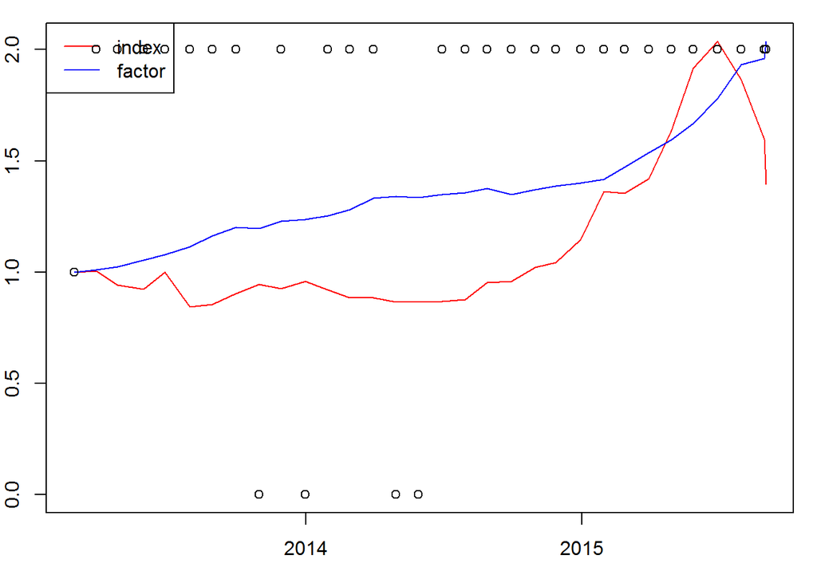

```
  average_t_value times_larger_than_threshold    rsquare
1         6.54379                   0.8709677 0.06354431
  average_factor_gain_year volatility_factor_gain
1                 32.02111               7.480909
```

## Trait Factors: Size

### What is size

Size factor is a rather fundamental character of a stock. It indicates the total shares of this company and thus showing the scale of this stock which is a decisive while complicated factor in Chinese A-share market.

### The grouped portofolio backtest result

```
[1] "size"
```

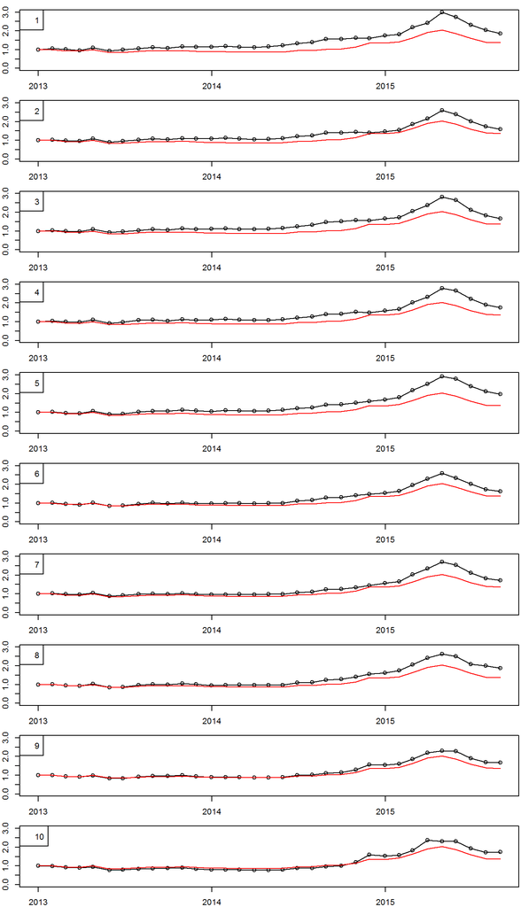

```
          [,1]      [,2]      [,3]      [,4]      [,5]      [,6]      [,7]
gain 1.8635788 1.5884173 1.6676086 1.7580560 1.9733651 1.6310262 1.7129972
     0.5471593 0.4325512 0.5038367 0.5024991 0.5765588 0.4768779 0.5122812
          [,8]      [,9]     [,10]
gain 1.8697322 1.6623183 1.7389903
     0.5272627 0.4568834 0.5083386
```

### The cross-section regression result

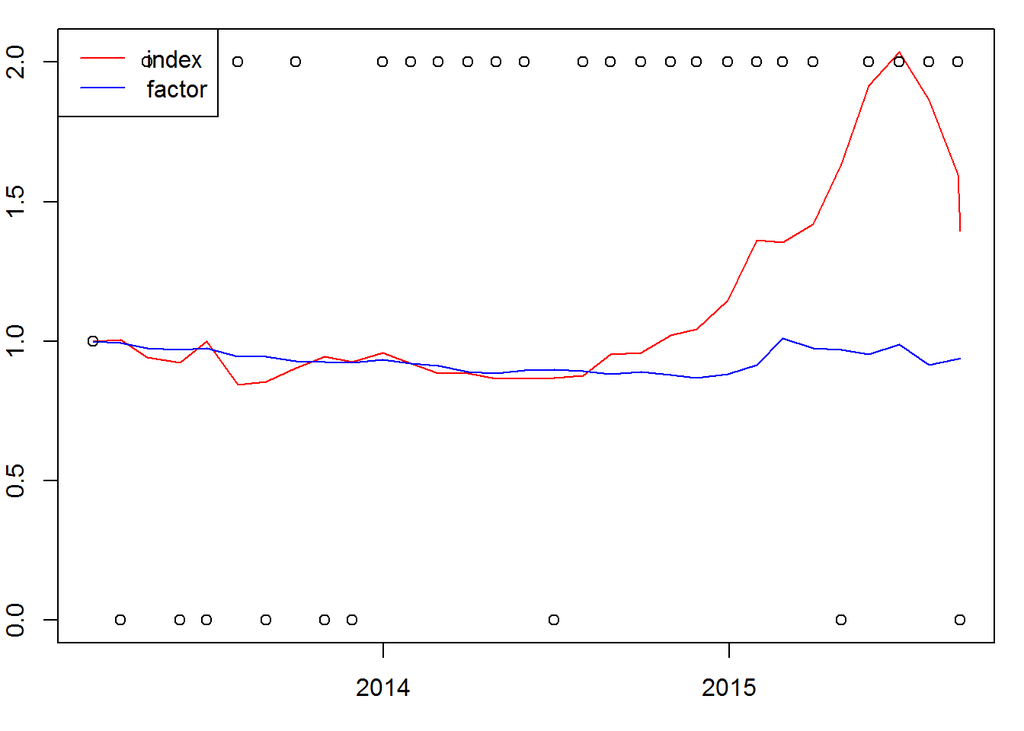

```
  average_t_value times_larger_than_threshold    rsquare
1        4.347548                   0.7096774 0.03347399
  average_factor_gain_year volatility_factor_gain
1                -1.899973               9.953076
```

As we can see from the regression result that the size factor does influence stock performance. But may not in a clear pattern and this factor may not generate ideal payoff. This result suggests to leave no risk exposure to size factor.

## Trait Factors: Consensus Expectation

### What is Consensus Expectation

Consensus Expectation is the unified opinion towards a stock from thousands of stock analysts. This factor is consisted of three sub-factors: the expected roe(Rate of Return on Common Stockholders’ Equity),the expected eps(earnings per share) and the average rating from analysts.  
The weight of each subfactor is determined by an optimization model whose target is to maximize the explanatory power of the new generated factor.

### The grouped portofolio backtest result

```
[1] "Consensus Expectation"
```

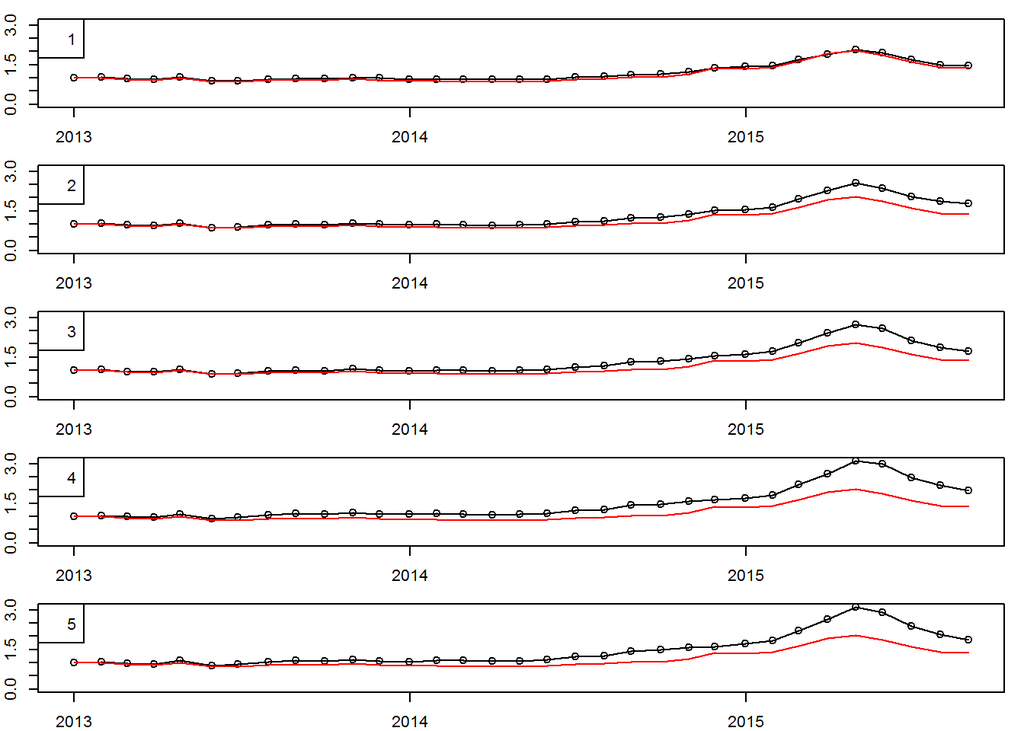

```
          [,1]      [,2]      [,3]      [,4]      [,5]
gain 1.4531344 1.7880166 1.7321237 1.9969561 1.8835541
     0.3435083 0.4840969 0.5306841 0.6177556 0.6096137
```

### The cross-section regression result

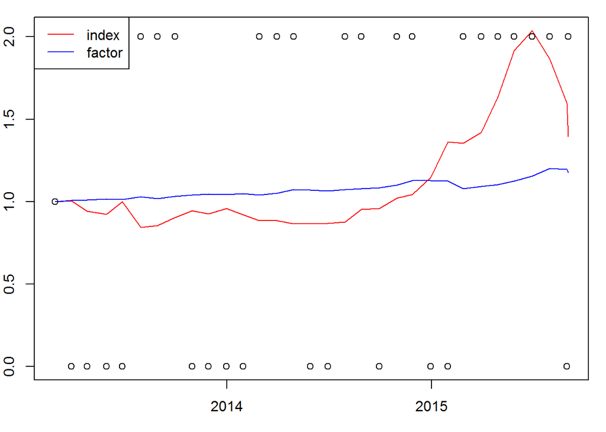

```
  average_t_value times_larger_than_threshold    rsquare
1         2.72611                   0.5483871 0.01308858
  average_factor_gain_year volatility_factor_gain
1                 6.600953               5.018281
```

## Trait Factors: Volatility

### What is Volatility

Volatility shows how severe does this stock swing in the past. In a broader way, I ddefine volatility as the risk factor. It indicates how dangerous and active this stock is.  
It is consisted of three sub-factors including the annual standard deviation of the monthly yield sequence for the last one hundred weeks and the last three years. Also, I include the turnover rate factor to indicate how actively is this stock being traded. The weight of each subfactor is determined by an optimization model whose target is to maximize the explanatory power of the new generated factor.

### The grouped portofolio backtest result

```
[1] "volatility"
```

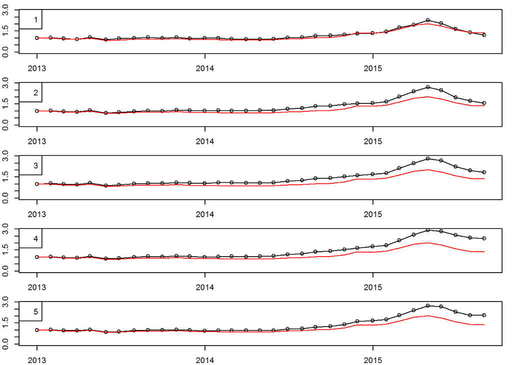

```
          [,1]      [,2]      [,3]      [,4]      [,5]
gain 1.2097871 1.5768101 1.8447268 2.3184581 2.0508528
     0.3575024 0.4937885 0.5409802 0.6329991 0.5666599
```

The plot suggests that the higher the volatility, the better the performance and top 20% to 40% give the best return. So this result suggests that active stocks may have larger risk yet better payoff.

### The cross-section regression result

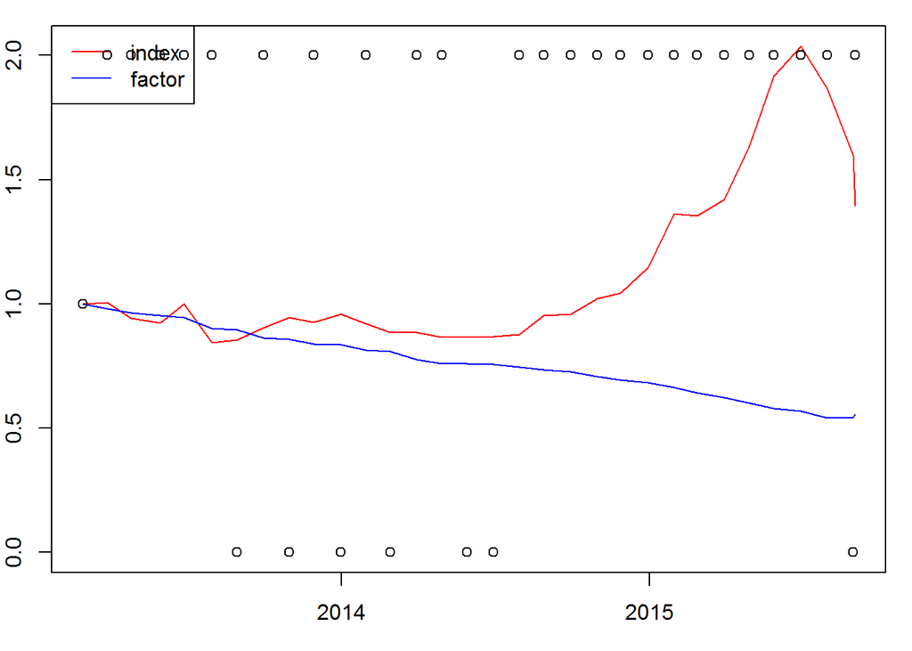

```
  average_t_value times_larger_than_threshold   rsquare
1        5.439729                   0.7741935 0.0465274
  average_factor_gain_year volatility_factor_gain
1                -20.28525               5.204972
```

Regression model helps us to decide whether risk is a good thing. It’s quite clear that taking too much risks may end up broken. Therefore we should definitely limit the risk exposure on volatility to zero while generating our factor strategy.

## Trait Factors: Growth

### What is Growth

Growth factor contains two aspects, the historical growth of this company and the estimated growth of it. Therefore, this growth factor is consisted of four sub factors: the estimated net profit growth, the estimated sales growth,the roe growth for last time period and the gross revenue growth rate. The weight of each subfactor is determined by an optimization model whose target is to maximize the explanatory power of the new generated factor.

### The grouped portofolio backtest result

```
[1] "growth"
```

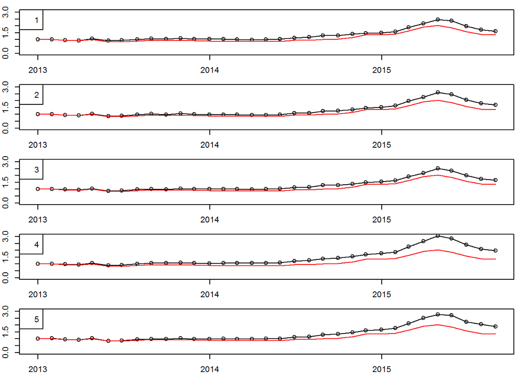

```
          [,1]      [,2]      [,3]      [,4]      [,5]
gain 1.6093567 1.6949786 1.6604517 1.9873654 1.9034398
     0.4352181 0.4901876 0.4566463 0.6123868 0.5710641
```

We can see from the plot that companies with high incidents in growth factor tend to perform better. However, it’s not clear whether it’s the higher the better or not. What definitely can be told is that a decent growth promises a better performance.

### The cross-section regression result

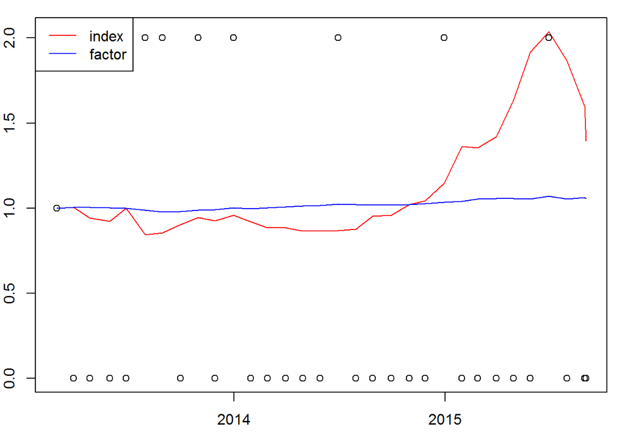

```
  average_t_value times_larger_than_threshold     rsquare
1        1.391899                   0.2258065 0.003410064
  average_factor_gain_year volatility_factor_gain
1                 2.226708               2.272134
```

The regression model result leads to a big surprise. The growth factor actually has a very small positive outcome. But this may be the consequence of regression data choice. We now use regression model to explain the performance with the data at the same time period. **However, growth data tends to influence the stock performance at the next period or even later. Besides, the time point we choose is not exactly the timepoint when the raw data is released. Beacuse, after all, these factors are mainly financial indicators and tend to be released in quarterly and yearly reports.** Consequently, I do not want to rush to a conclusion toward whether the growth factor is a good one or not, it will be discussed with more detail in the following reports.

## Trait Factors: Value

### What is Value

Value indicates the valuation level of the stock. Despite the fact that lots of indicators can be applied to demonstrate the valuation level, I find them all too much similar that causes collinearity. Actually, the single PB-TTM factor is well qualified to serve as the value indicator. Here we actually use the reciprocal of PB.

### The grouped portofolio backtest result

```
[1] "value"
```

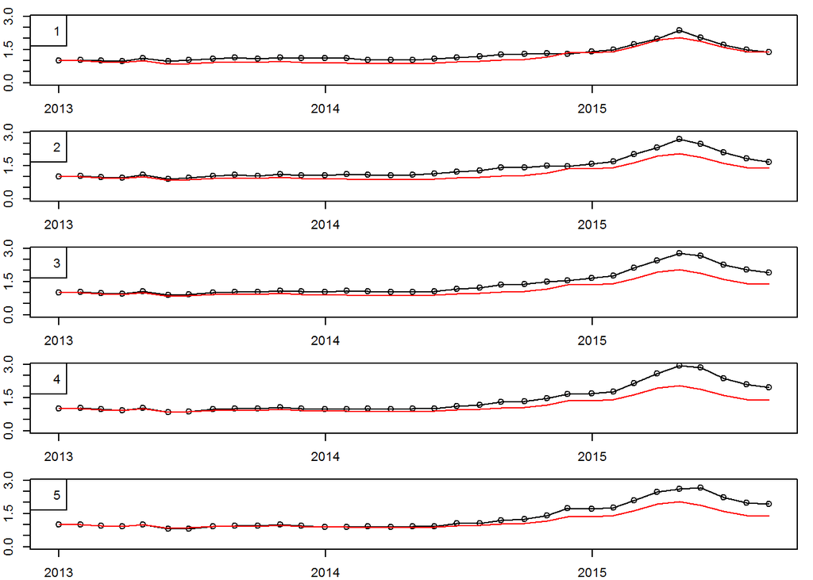

```
          [,1]     [,2]      [,3]      [,4]      [,5]
gain 1.3670905 1.661747 1.9057346 1.9625849 1.9163527
     0.3403885 0.477320 0.5466945 0.6072014 0.5744059
```

These plots indicates that those stocks with low evaluation level tend to become profitable while those overestimated shares will devalue. However, it’s best to rank in the bottom 20 to 40 percent rather than the lowest in order to perform best.

### The cross-section regression result

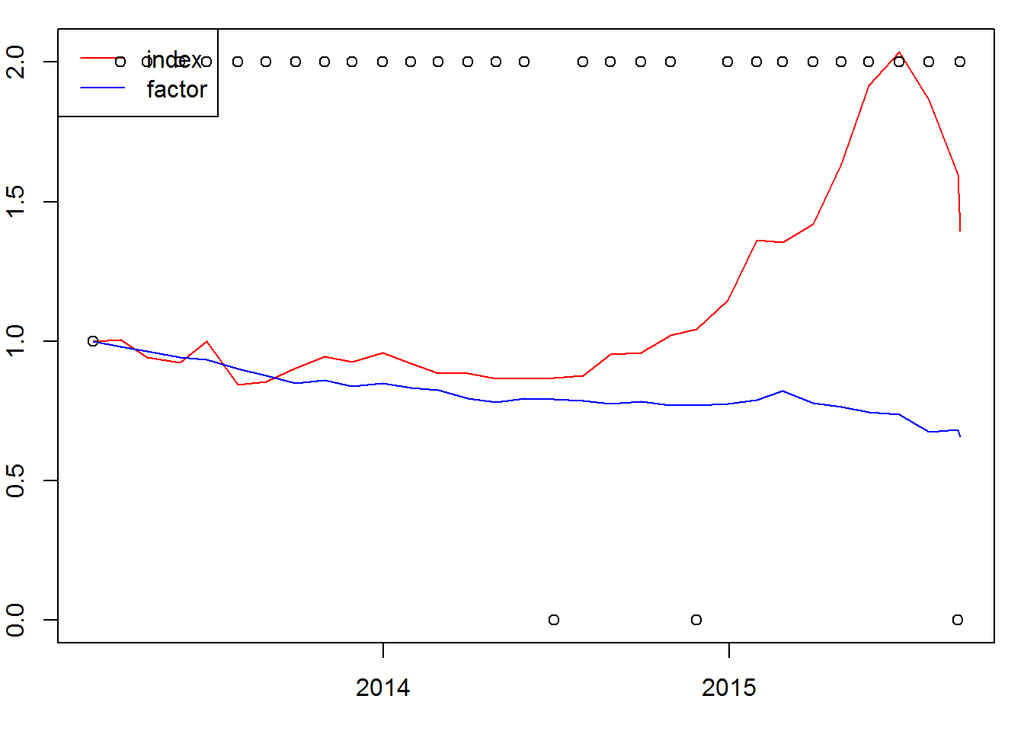

```
  average_t_value times_larger_than_threshold    rsquare
1        5.451005                   0.9032258 0.04391627
  average_factor_gain_year volatility_factor_gain
1                -14.57273               8.214382
```

## Trait Factors: Leverage

### What is Leverage

Leverage is the factor showing the debt burden of the company. It is consisted of four sub factors: debt ratio, long time debt ratio, debt paying ability, long time debt paying ability. Here we actually use the reciprocal of these factors. The weight of each subfactor is determined by an optimization model whose target is to maximize the explanatory power of the new generated factor.

### The grouped portofolio backtest result

```
[1] "leverage"
```

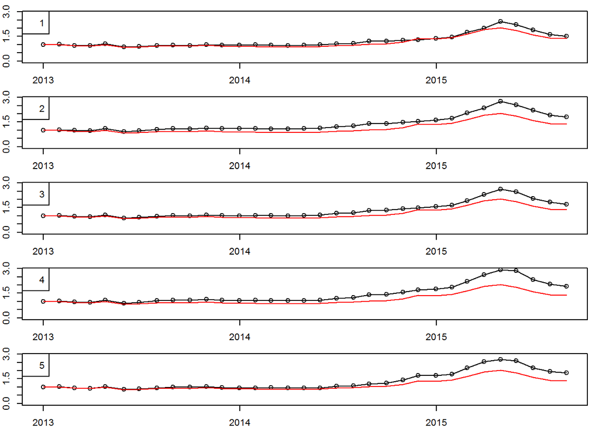

```
         [,1]     [,2]      [,3]     [,4]      [,5]
gain 1.521425 1.804271 1.7040369 1.918482 1.8634170
     0.410194 0.502542 0.4831758 0.592107 0.5626551
```

It’s hard to tell any conclusion for sure from this plot.

### The cross-section regression result

```
[1] "leverage"
```

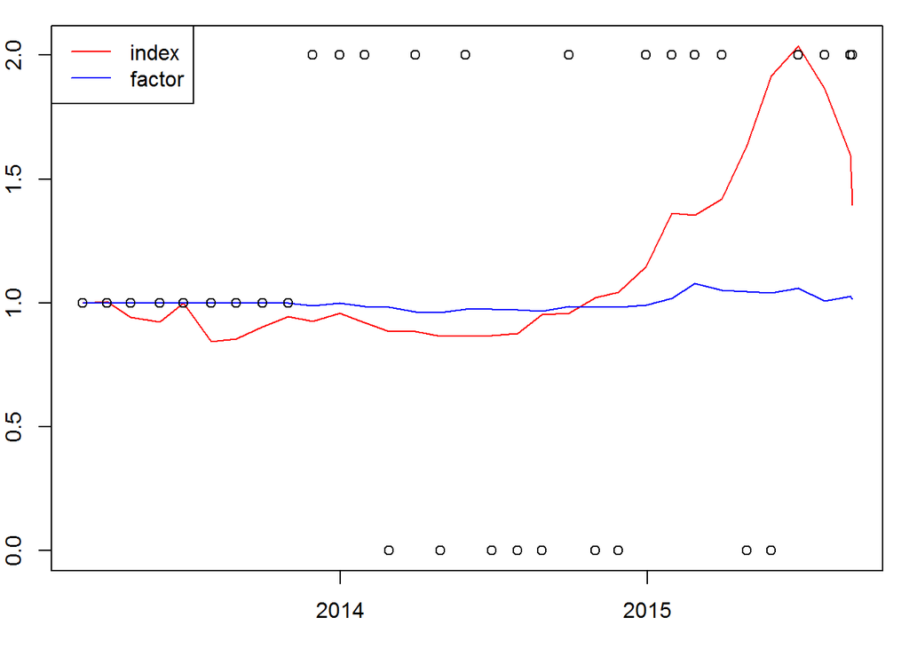

```
  average_t_value times_larger_than_threshold    rsquare
1        3.146083                   0.6086957 0.01748063
  average_factor_gain_year volatility_factor_gain
1                 1.078987               7.054694
```

The regression result doesn’t clear much ambiguity of this factor. In cosideration of the huge difficult of obtaining the raw data for this factor, it doesn’t qualified to be a decent factor.

## Trait Factors: News

### What is News

News is the factor measuring the market heat level of a particular stock. It includes data from [XueQiu](http://xueqiu.com/), a widely accepted and frequently used online forum to discuss stocks in Chinese stock market. The News factor is consisted of four sub factors including the newly increased population who focuses, discusses and shares trade history about this stock during last obervation period. Also, the average inventory per account is taken into consideration since it has been proved by much experience as a useful factor.  
The weight of each subfactor is determined by an optimization model whose target is to maximize the explanatory power of the new generated factor.

### The grouped portofolio backtest result

```
[1] "news"
```

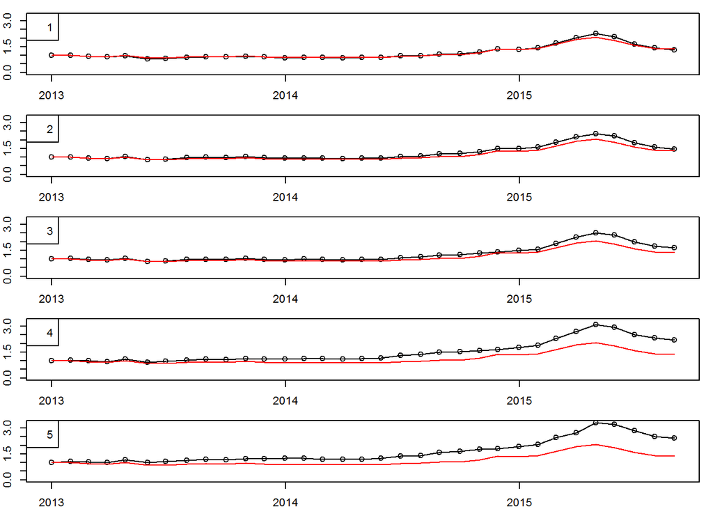

```
          [,1]      [,2]     [,3]      [,4]      [,5]
gain 1.3070402 1.4695820 1.641385 2.2022952 2.4247232
     0.3914615 0.4321049 0.466475 0.6313889 0.6861911
```

The portofolio backtest result indicates that high marks in News factor obviously lead to better payoff. What’s even better is that the higher the factor indication, the more the payoff.

### The cross-section regression result

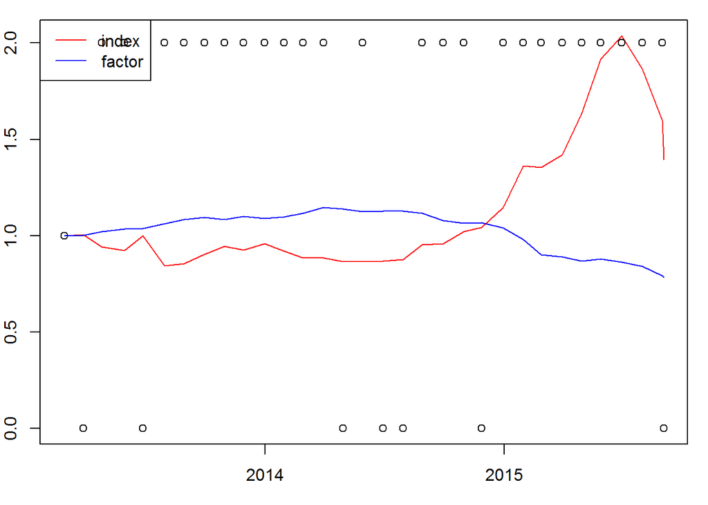

```
  average_t_value times_larger_than_threshold    rsquare
1        4.676988                   0.7741935 0.03862131
  average_factor_gain_year volatility_factor_gain
1                -8.645025               8.722447
```

**Conclusion**

This factor is a rather new one, the data offered is somehow messy and its real effect remains much unclear. Since the backtest and the regression model offer opposite conclusions, I put my final conclusion as unclear for this factor.

## Industry factors

### What is industry factors

Industry factors are set on the reference of the CITIC primary industry classification, which includes 29 industries. I treat it as a factor variable. That is, if this stock belongs to the first industry class than it will get “yes” for the first industry variable and “no” for the rest.

### The first glance at industry factors

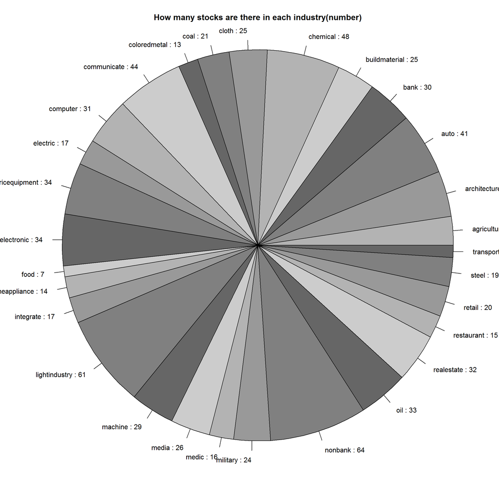

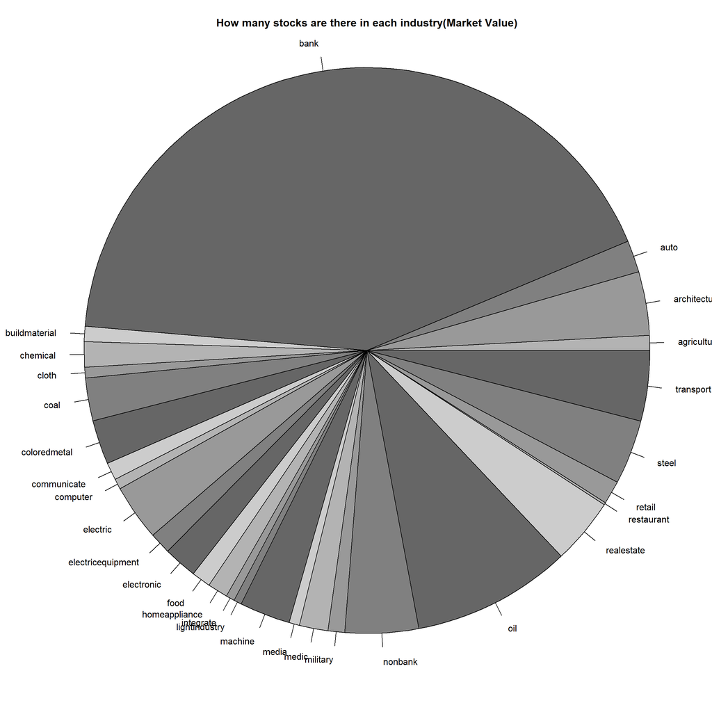

### The grouped portofolio backtest result

For each factor, we group our samples into two portofolios: those stocks in this industry and all the others. And we observe their performance.

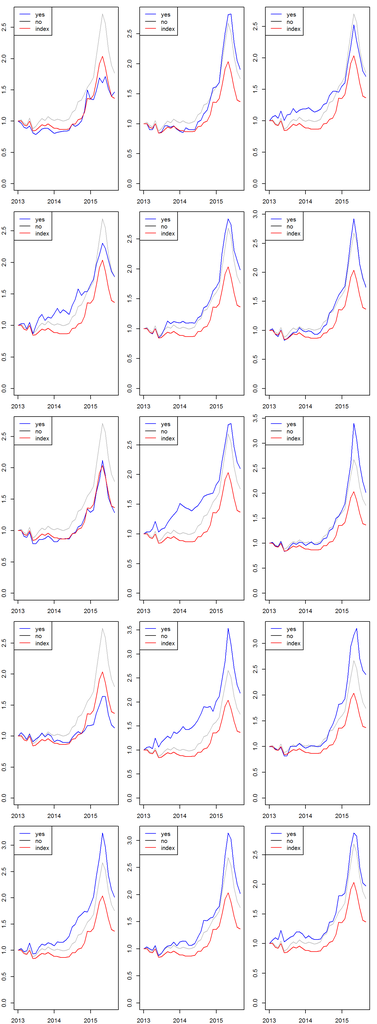

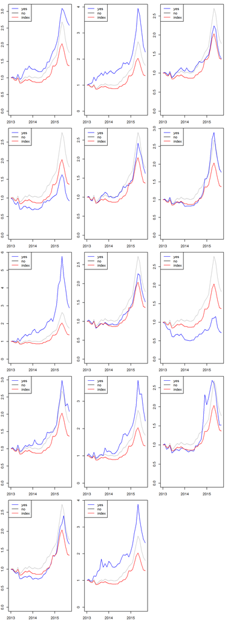

*************** #### What does the plot mean The blue line is the portofolio consist of stocks in that particular industry while the grey one is those outside this industry. The red line is the reference index of CSI 800. **Unlike CSI 800 which determines each component stock’s weight according to their market value, the portofolios of mine give equal weights to each and every component stock. Hence the influence of size factor can be removed.**

As we can tell from all plots, the industry factors do have obvious effect on stock payoff. However the way of influence motifies with time and industries. It suggests that industry is a powerful yet not tame factor. The best option might be trying to exclude the influence of it rather than manipulating it.

### The cross-section regression result

We then use one factor regression model to precisely determine the significance level and also the percentage of contribution of each industry factor.

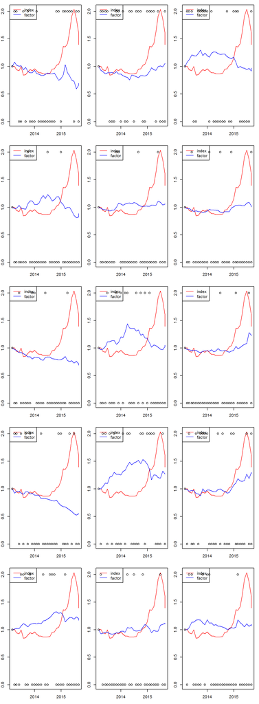

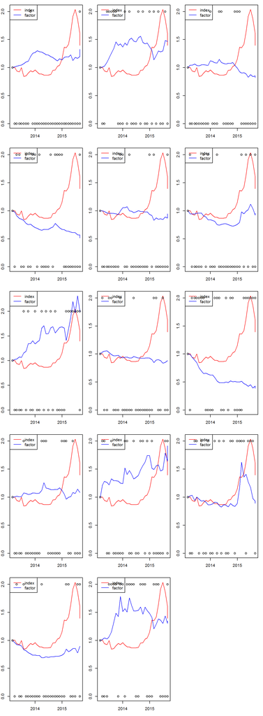

It’s clear to see that industry performance vary largely from industry to industry. It agrees with the result of the backtest result that industry factor is too dangerous to manipulate. The best option is to maintain an industry-neutral portofolio.

**Conclusion**

| Industry |  |  |  |
| --- | --- | --- | --- |
| WindCode: | Citic | T-value: | 2(avg) |
| Effective: | Unclear | Effective%: | 50%(avg) |
| Way Of Effect: | Unclear | FactorGain: | Unclear |
| MissingData%: | 0/23142 |  |  |

# Part Two: The Neutral Strategy Report